# R Notebook

```r
install.packages("ggplot2")
library(ggplot2)
```

```r
install.packages("dplyr")
library(dplyr)
```

```r
install.packages("qcc")
library(qcc)
```

```r
install.packages("RMysql")
library(RMySQL)
```

# Connecting R with database freight in MySQL

```r
con=dbConnect(MySQL(),
              user='root', password ="",
dbname = 'freight', host ='127.0.0.1')
```

# Getting the table airExport with statistics from CG (2012-2016)

```r
result<-dbGetQuery(con, statement = "SELECT*FROM airExport")
```

# Graphic the QUantity of Shipments per Year

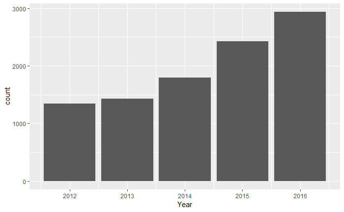

```r
ggplot(data = result) +
  geom_bar(mapping = aes(x = Year, colour = Year))
```

```r
byMonthYear <- group_by(result, Year, Month)
Summary <- summarise(byMonthYear,
  count = n(), sum(Chargeable_weight))
Summary
```

| Year | Month | count | sum(Chargeable_weight) |
| --- | --- | --- | --- |
| 2012 | 1 | 83 | 33243.00 |
| 2012 | 2 | 90 | 29642.48 |
| 2012 | 3 | 126 | 49501.47 |
| 2012 | 4 | 100 | 47767.00 |
| 2012 | 5 | 107 | 26873.00 |
| 2012 | 6 | 96 | 25520.06 |
| 2012 | 7 | 124 | 42907.32 |
| 2012 | 8 | 142 | 61485.00 |
| 2012 | 9 | 113 | 38794.00 |
| 2012 | 10 | 138 | 41080.00 |

[output cut: 50 more lines]

# Defining variable Quantity of Shipments per month

```r
QtyShipments<-count(byMonthYear)
```

# Creating Time Series for Quantity of shipments

```r
tsData<-ts (QtyShipments$n, start=c(2012), frequency=12)
tsData
```

```
     Jan Feb Mar Apr May Jun Jul Aug Sep Oct Nov Dec
2012  83  90 126 100 107  96 124 142 113 138 127  97
2013 112  93 128 139 115 114 114 137 123 134 105 114
2014 109  93 132 126 165 136 159 166 180 189 162 183
2015 199 156 188 192 201 203 211 200 228 236 224 185
2016 180 203 232 267 242 284 246 311 270 232 214 257
```

# Decomposing the series to check the impact of Trend, Seasonality and Random

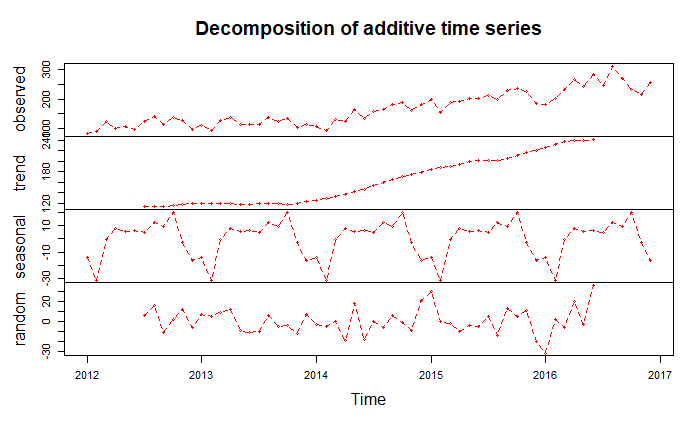

```r
decomposedRes <- decompose(tsData, type="additive")
stlRes <- stl(tsData, s.window = "periodic")
plot (decomposedRes, type="o", col="red", lty="dashed")
```

```r
decomposedRes
```

```
$x
     Jan Feb Mar Apr May Jun Jul Aug Sep Oct Nov Dec
2012  83  90 126 100 107  96 124 142 113 138 127  97
2013 112  93 128 139 115 114 114 137 123 134 105 114
2014 109  93 132 126 165 136 159 166 180 189 162 183
2015 199 156 188 192 201 203 211 200 228 236 224 185
2016 180 203 232 267 242 284 246 311 270 232 214 257

$seasonal
             Jan         Feb         Mar         Apr         May         Jun         Jul
2012 -14.2612847 -31.0425347  -0.6883681   7.6970486   5.5616319   6.4887153   4.7907986
2013 -14.2612847 -31.0425347  -0.6883681   7.6970486   5.5616319   6.4887153   4.7907986
2014 -14.2612847 -31.0425347  -0.6883681   7.6970486   5.5616319   6.4887153   4.7907986
2015 -14.2612847 -31.0425347  -0.6883681   7.6970486   5.5616319   6.4887153   4.7907986
2016 -14.2612847 -31.0425347  -0.6883681   7.6970486   5.5616319   6.4887153   4.7907986
             Aug         Sep         Oct         Nov         Dec
2012  11.8532986   9.3220486  19.7282986  -3.1675347 -16.2821181
2013  11.8532986   9.3220486  19.7282986  -3.1675347 -16.2821181
2014  11.8532986   9.3220486  19.7282986  -3.1675347 -16.2821181
2015  11.8532986   9.3220486  19.7282986  -3.1675347 -16.2821181
2016  11.8532986   9.3220486  19.7282986  -3.1675347 -16.2821181

$trend
          Jan      Feb      Mar      Apr      May      Jun      Jul      Aug      Sep
2012       NA       NA       NA       NA       NA       NA 113.1250 114.4583 114.6667
2013 119.7500 119.1250 119.3333 119.5833 118.5000 118.2917 118.8750 118.7500 118.9167
2014 125.8750 128.9583 132.5417 137.2083 141.8750 147.1250 153.7500 160.1250 165.0833
2015 183.6667 187.2500 190.6667 194.6250 199.1667 201.8333 201.1250 202.2917 206.0833
2016 225.7917 231.8750 238.2500 239.8333 239.2500 241.8333       NA       NA       NA
          Oct      Nov      Dec
2012 116.3750 118.3333 119.4167
2013 118.5417 120.0833 123.0833
2014 170.1667 174.4167 178.7083
2015 211.0417 215.8750 220.9583
2016       NA       NA       NA

$random
             Jan         Feb         Mar         Apr         May         Jun         Jul
2012          NA          NA          NA          NA          NA          NA   6.0842014
2013   6.5112847   4.9175347   9.3550347  11.7196181  -9.0616319 -10.7803819  -9.6657986
2014  -2.6137153  -4.9157986   0.1467014 -18.9053819  17.5633681 -17.6137153   0.4592014
2015  29.5946181  -0.2074653  -1.9782986 -10.3220486  -3.7282986  -5.3220486   5.0842014
2016 -31.5303819   2.1675347  -5.5616319  19.4696181  -2.8116319  35.6779514          NA
             Aug         Sep         Oct         Nov         Dec
2012  15.6883681 -10.9887153   1.8967014  11.8342014  -6.1345486
2013   6.3967014  -5.2387153  -4.2699653 -11.9157986   7.1987847
2014  -5.9782986   5.5946181  -0.8949653  -9.2491319  20.5737847
2015 -14.1449653  12.5946181   5.2300347  11.2925347 -19.6762153
2016          NA          NA          NA          NA          NA

$figure
 [1] -14.2612847 -31.0425347  -0.6883681   7.6970486   5.5616319   6.4887153   4.7907986
 [8]  11.8532986   9.3220486  19.7282986  -3.1675347 -16.2821181

$type
[1] "additive"

attr(,"class")
[1] "decomposed.ts"
```

# Grouping the data by Month and Year defining Quantity of Shipments and Chargeable Weight per month

```r
byMonthYear <- group_by(result, Year, Month)
Summary <- summarise(byMonthYear,
  count = n(), sum(Chargeable_weight))
Summary
```

| Year | Month | count | sum(Chargeable_weight) |
| --- | --- | --- | --- |
| 2012 | 1 | 83 | 33243.00 |
| 2012 | 2 | 90 | 29642.48 |
| 2012 | 3 | 126 | 49501.47 |
| 2012 | 4 | 100 | 47767.00 |
| 2012 | 5 | 107 | 26873.00 |
| 2012 | 6 | 96 | 25520.06 |
| 2012 | 7 | 124 | 42907.32 |
| 2012 | 8 | 142 | 61485.00 |
| 2012 | 9 | 113 | 38794.00 |
| 2012 | 10 | 138 | 41080.00 |

[output cut: 50 more lines]

# Defining variable Quantity of Shipments per month

```r
QtyShipments<-count(byMonthYear)
```

# Defining variable Chargeable Weight per month

```r
ChWperMonth<-summarise(byMonthYear,sum(Chargeable_weight))
ChWperMonth
```

| Year | Month | sum(Chargeable_weight) |
| --- | --- | --- |
| 2012 | 1 | 33243.00 |
| 2012 | 2 | 29642.48 |
| 2012 | 3 | 49501.47 |
| 2012 | 4 | 47767.00 |
| 2012 | 5 | 26873.00 |
| 2012 | 6 | 25520.06 |
| 2012 | 7 | 42907.32 |
| 2012 | 8 | 61485.00 |
| 2012 | 9 | 38794.00 |
| 2012 | 10 | 41080.00 |

[output cut: 50 more lines]

# Getting the correlation coefficient between Quantity of Shipments per month and Chargeable Weight per month

```r
cat("Correlation coefficient",cor(QtyShipments$n, ChWperMonth$`sum(Chargeable_weight)`))
```

```
Correlation coefficient 0.7876626
```

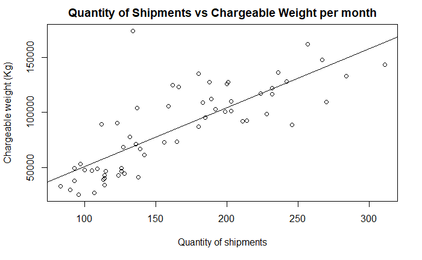

```r
plot(x=QtyShipments$n,y=ChWperMonth$`sum(Chargeable_weight)`,
     xlab="Quantity of shipments",
     ylab="Chargeable weight (Kg)",
     main= "Quantity of Shipments vs Chargeable Weight per month",
     abline(relation)
     )
```

It’s a high correlation coefficient together with a line that fits in the model of Linear Regression, which means that Quantity of Shipments per month and Chargeable weight per month are dependants and Chargeable weight could be estimated through a Linear Regresion Model by Quantity of Shipments

# Getting the Linear Regression Ecuation

```r
relation <- lm(ChWperMonth$`sum(Chargeable_weight)` ~ QtyShipments$n,data=result)
relation
```

```
Call:
lm(formula = ChWperMonth$`sum(Chargeable_weight)` ~ QtyShipments$n,
    data = result)

Coefficients:
   (Intercept)  QtyShipments$n
       -2544.1           533.8
```

Chargeable weight per month= QUantity of Shipments*533.8 - 2544.1

# If the Company could low the selling rates in a 10%, Sales could get 20% more of shipments. Lets calculate the average of Quantity of shipments for 2016 to simulate a 20% increase of operations for the following Year

```r
year2016<-subset(result,Year=="2016")
byMonthYear2016 <- group_by(year2016, Year, Month)
QtyShipments2016<-count(byMonthYear2016)
AveQtyShipments2016<-mean(QtyShipments2016$n)
cat("Average Shipments per month 2016:",AveQtyShipments2016)
```

```
Average Shipments per month 2016: 244.8333
```

```r
ChWperMonth2016<-summarise(byMonthYear2016,sum(Chargeable_weight))
AveChWperMonth2016<-mean(ChWperMonth2016$`sum(Chargeable_weight)`)
cat("Average Chargeable Weight per month 2016:",AveChWperMonth2016)
```

```
Average Chargeable Weight per month 2016: 119211.6
```

# Lets estimate an increase of the Quantity of shipments per month through the average according to the Forecast of Sales assuming that Pricing can get a reduction of 10% on the buying rates

```r
ShipmentsIncreased<-mean(QtyShipments2016$n)*1.2
cat("Shipments per month increased in a 20%:",ShipmentsIncreased)
```

```
Shipments per month increased in a 20%: 293.8
```

# To predict the increasing of chargeable weight, let’s use the quantity of shipments per month estimated with the increasing of 20%.

-Predict function: predict(relation, given Quantity of shipments)

```r
shipmentsInc<-data.frame(QtyShipments$n==294)
estChgwMonth <- predict(relation, shipmentsInc)
estChgwMonth
```

```
        1         2         3         4         5         6         7         8         9
 41761.13  45497.72  64714.43  50835.69  54572.28  48700.50  63646.84  73255.20  57775.06
       10        11        12        13        14        15        16        17        18
 71120.01  65248.23  49234.30  57241.27  47099.11  65782.03  71653.80  58842.66  58308.86
       19        20        21        22        23        24        25        26        27
 58308.86  70586.21  63113.04  68984.82  53504.68  58308.86  55639.87  47099.11  67917.22
       28        29        30        31        32        33        34        35        36
 64714.43  85532.55  70052.41  82329.76  86066.34  93539.51  98343.69  83931.15  95140.90
       37        38        39        40        41        42        43        44        45
103681.67  80728.37  97809.89  99945.08 104749.26 105816.86 110087.24 104215.47 119161.80
       46        47        48        49        50        51        52        53        54
123432.18 117026.61  96208.50  93539.51 105816.86 121296.99 139979.91 126634.97 149054.47
       55        56        57        58        59        60
128770.16 163467.01 141581.31 121296.99 111688.63 134641.93
```

The function predict is used to estimate Chargeable weight through the linear regression ecuation, for some reason is returning 60 values when it should return 1 value for Quantity of shipments=294. Simulating in the linear equation for 294 shipments, the chargeable weight estimated is 154393.1 Kg. If the average for Chargeable weight per month estimated for 2016 was 119211.6 Kg, and the Chargeable weight estimated for the new level of Operations (through the linear regression) was 154393.1Kg we could compare both values to check the difference between them

```r
difChgw<-(154393.1/AveChWperMonth2016-1)*100
cat("Increase of the Average of Chargeable weight per month:",difChgw,"%")
```

```
Increase of the Average of Chargeable weight per month: 29.51184 %
```

the difference is higher than 20%, then the recommendation to the Company is to get a commitment with the Airlines confirming that they could bring to the table at least 20% more of Cargo (Chargeable weight)

# The Company focuse the efforts through Paretto Principle for main destinations, main customers and Main Airlines.

Grouping by Main destinations to Apply Paretto

```r
byAirport <- group_by(result, CodeDestinationAirport)
destination <- summarise(byAirport,
  "Shipments"= n(), "Chargeable"=sum(Chargeable_weight))
sortdestination <- destination[order(-destination$Shipments),]
sortdestination
```

| CodeDestinationAirport | Shipments | Chargeable |
| --- | --- | --- |
| CNF | 3314 | 1512253.99 |
| GRU | 2129 | 923658.77 |
| VCP | 1102 | 1385083.08 |
| GIG | 982 | 274359.45 |
| REC | 398 | 365174.02 |
| MAO | 387 | 161420.49 |
| CWB | 250 | 64060.23 |
| SCL | 243 | 143409.99 |
| BEL | 239 | 62670.76 |
| VIX | 155 | 48501.52 |

[output cut: 50 more lines]

# Finding the vital destinations and grouping in “others”" the Trivial destinations according to the Quantity of shipments per destination

```r
trivialsAirport<-subset(destination,Shipments<390)
mainAirport<-subset(destination,Shipments>=390)
otherAirport<-data.frame("CodeDestinationAirport"="others","Shipments"=sum(trivialsAirport$Shipments),"Chargeable"=sum(trivialsAirport$Chargeable))
destParetoAirport<-rbind(mainAirport,otherAirport)
destParetoAirport$frequency<-prop.table(destParetoAirport$Shipments)
destParetoAirport$cumFrequency<-cumsum(destParetoAirport$frequency)
destParetoAirport
```

| CodeDestinationAirport | Shipments | Chargeable | frequency | cumFrequency |
| --- | --- | --- | --- | --- |
| CNF | 3314 | 1512254.0 | 0.33366895 | 0.3336689 |
| GIG | 982 | 274359.5 | 0.09887233 | 0.4325413 |
| GRU | 2129 | 923658.8 | 0.21435763 | 0.6468989 |
| REC | 398 | 365174.0 | 0.04007249 | 0.6869714 |
| VCP | 1102 | 1385083.1 | 0.11095449 | 0.7979259 |
| others | 2007 | 688504.9 | 0.20207410 | 1.0000000 |

```r
TipoAirport<-destParetoAirport$Shipments
names(TipoAirport)<-(destParetoAirport$CodeDestinationAirport)
TipoAirport
```

```
   CNF    GIG    GRU    REC    VCP others
  3314    982   2129    398   1102   2007
```

```
In seq.default(0, 100, by = 20, ylim = 80) :
 extra argument 㤼㸱ylim㤼㸲 will be disregarded
```

```
Pareto chart analysis for TipoAirport
           Frequency   Cum.Freq.  Percentage Cum.Percent.
  CNF    3314.000000 3314.000000   33.366895    33.366895
  GRU    2129.000000 5443.000000   21.435763    54.802658
  others 2007.000000 7450.000000   20.207410    75.010068
  VCP    1102.000000 8552.000000   11.095449    86.105518
  GIG     982.000000 9534.000000    9.887233    95.992751
  REC     398.000000 9932.000000    4.007249   100.000000
```

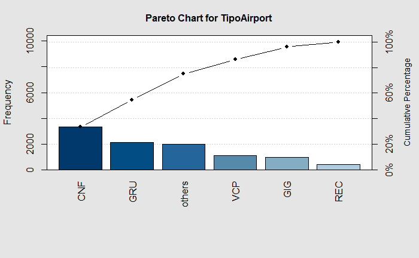

```r
pareto.chart(TipoAirport,cumperc=seq(0,100,by=20,ylim=80))
```

# Finding the vital Airlines used and grouping in “others”" the Trivial Airlines used according to the Quantity of shipments per Airline

```r
byAirline <- group_by(result, Airline)
airline <- summarise(byAirline,
  "Shipments"= n(), "Chargeable"=sum(Chargeable_weight))
sortairline <- airline[order(-airline$Shipments),]
sortairline
```

| Airline | Shipments | Chargeable |
| --- | --- | --- |
| LAN CARGO | 3830 | 1267087.38 |
| AMERICAN AIRLINES | 2739 | 779013.00 |
| ATLAS AIR CARGO | 842 | 1273213.54 |
| ABSA AEROLINEAS BRASILEIRAS SA | 605 | 784336.58 |
| BRINGER AIR CARGO | 369 | 140280.47 |
| TAP - AIR PORTUGAL | 361 | 119061.90 |
| TAMPA CARGO | 350 | 86673.19 |
| MERCURY AIR CARGO INC | 262 | 418381.54 |
| CENTURION CARGO | 223 | 89338.67 |
| AZUL LINHAS AEREAS BRASILEIRAS | 183 | 96332.61 |

[output cut: 10 more lines]

```r
trivialsAirlines<-subset(airline,Shipments<370)
mainAirlines<-subset(airline,Shipments>=370)
otherAirlines<-data.frame("Airline"="others","Shipments"=sum(trivialsAirlines$Shipments),"Chargeable"=sum(trivialsAirlines$Chargeable))
destParetoAirlines<-rbind(mainAirlines,otherAirlines)
destParetoAirlines$frequency<-prop.table(destParetoAirlines$Shipments)
destParetoAirlines$cumFrequency<-cumsum(destParetoAirlines$frequency)
destParetoAirlines
```

| Airline | Shipments | Chargeable | frequency | cumFrequency |
| --- | --- | --- | --- | --- |
| ABSA AEROLINEAS BRASILEIRAS SA | 605 | 784336.6 | 0.06091422 | 0.06091422 |
| AMERICAN AIRLINES | 2739 | 779013.0 | 0.27577527 | 0.33668949 |
| ATLAS AIR CARGO | 842 | 1273213.5 | 0.08477648 | 0.42146597 |
| LAN CARGO | 3830 | 1267087.4 | 0.38562223 | 0.80708820 |
| others | 1916 | 1045383.7 | 0.19291180 | 1.00000000 |

```r
TipoAirline<-destParetoAirlines$Shipments
names(TipoAirline)<-(destParetoAirlines$Airline)
TipoAirline
```

```
ABSA AEROLINEAS BRASILEIRAS SA              AMERICAN AIRLINES
                           605                           2739
               ATLAS AIR CARGO                      LAN CARGO
                           842                           3830
                        others
                          1916
```

```
In seq.default(0, 100, by = 20, ylim = 80) :
 extra argument 㤼㸱ylim㤼㸲 will be disregarded
```

```
Pareto chart analysis for TipoAirline
                                   Frequency   Cum.Freq.  Percentage Cum.Percent.
  LAN CARGO                      3830.000000 3830.000000   38.562223    38.562223
  AMERICAN AIRLINES              2739.000000 6569.000000   27.577527    66.139750
  others                         1916.000000 8485.000000   19.291180    85.430930
  ATLAS AIR CARGO                 842.000000 9327.000000    8.477648    93.908578
  ABSA AEROLINEAS BRASILEIRAS SA  605.000000 9932.000000    6.091422   100.000000
```

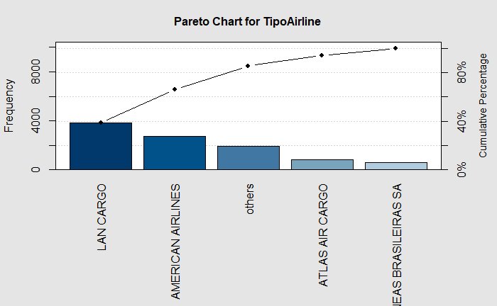

```r
pareto.chart(TipoAirline,cumperc=seq(0,100,by=20,ylim=80))
```